# Wreck project

Philéas

Saturday, February 07, 2015

L’objet de ce document est de chiffrer pistes d’amélioration du processus de gestion des épaves et réparations.

Quelques chiffres pour indiquer les volumes :

```
##       meanVRADEvei              nbvei       VRADEmVRESID
##       3.883176e+03       5.309200e+04       3.654617e+03
##            meanREP              nbrep  totveiVRADEmRESID
##       1.364843e+03       3.517450e+05       1.940309e+08
## totveiVRADEmRESCES             totrep
##       1.731690e+08       4.800768e+08
```

Répartition des VRADE des VEI :

- 75% valent moins de 5000€
- ~50% valent moins de 2500€

La prise en compte de la valeur résiduelle a un effet faible mais sensible

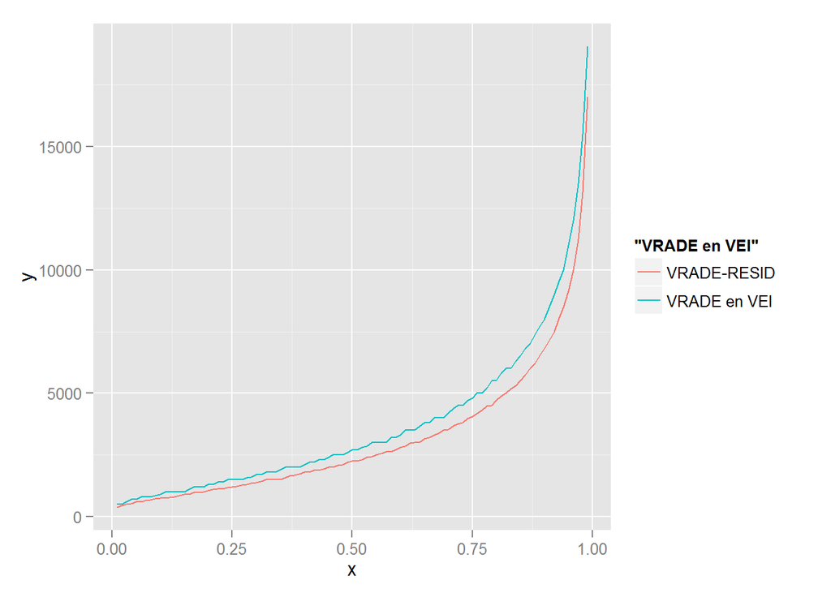

Répartition des valeurs résiduelles des VEI

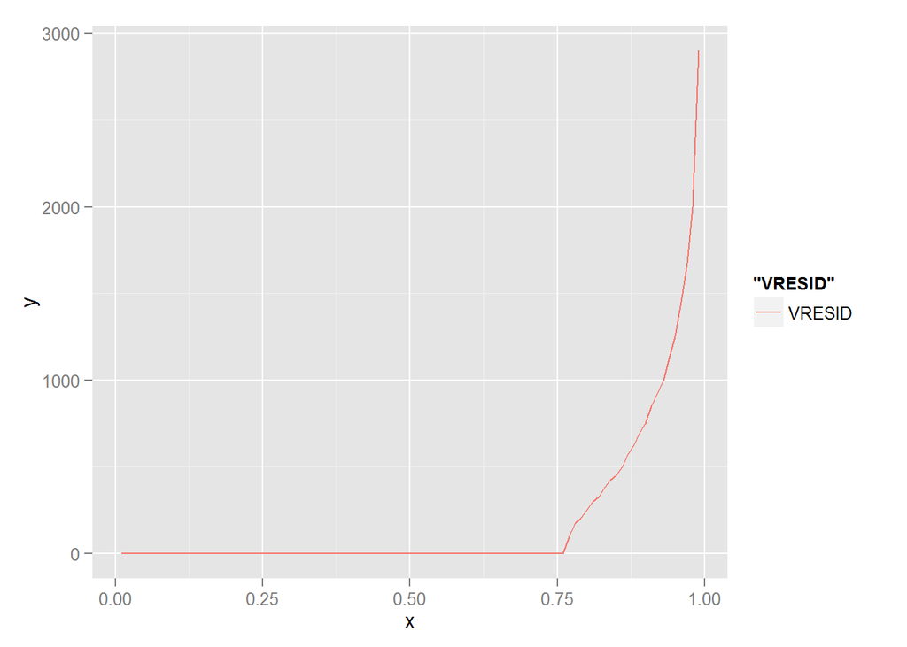

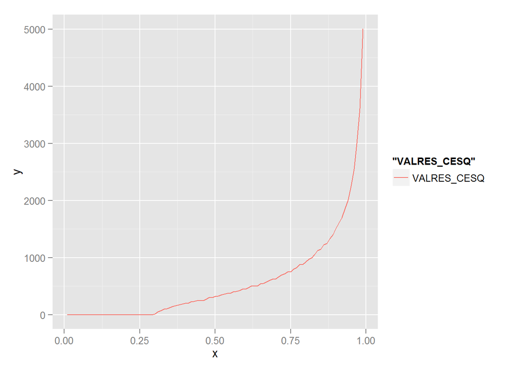

Si on regarde de plus près on se rend compte que la valeur résiduelle n’est pas forfaitaire (0% ou 25%) dans 13833 cas.

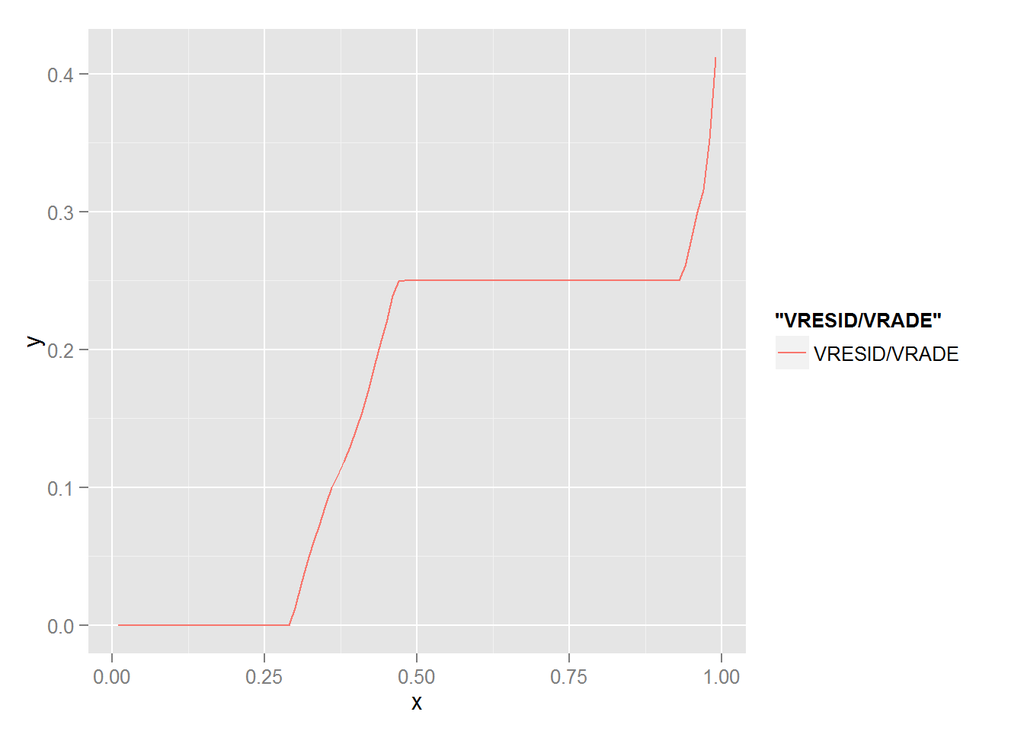

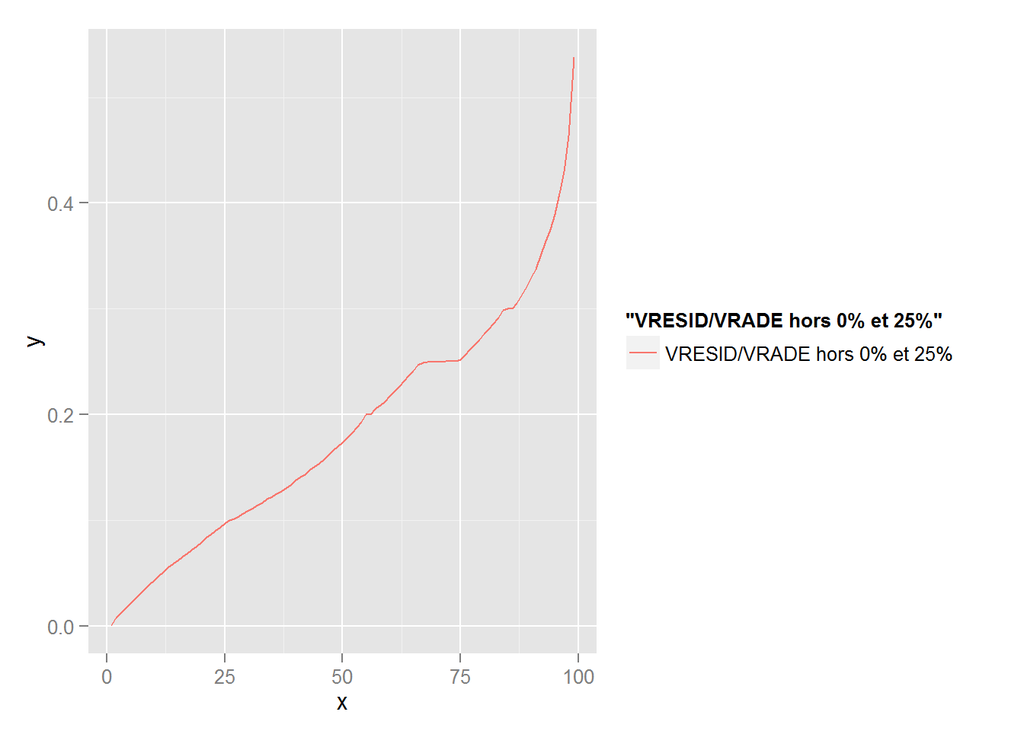

- On essaie de modéliser cette valeur résiduelle (hors 0 et 25% VRADE) en tant que part de la VRADE. Aucun pouvoir explicatif avec les variables à disposition. On utilise : prix à neuf, kilométrage, âge, valeur des pièces, énergie, genre, classe, modèle, VRADE.
- Si on essaie d’expliquer directement la valeur résiduelle on obtient des résultats médiocres : écart type de 500€ pour des valeurs résiduelles en moyenne à 600€.
- Si on s’intéresse aux valeurs résiduelles de plus de 500€ (on en compte 6500), on obtient une erreur de 1300€ pour une valeur résiduelle moyenne de 2000€.

Les variables les plus influentes sont 1] VRADE (2/3), 2] modèle (1/3 et overfitting important)

L’ajout de variables (précisions sur les chocs ?), mais surtout d’observations, permettra de faire mieux.

On pourrait aussi tirer profit de la valeur MTHTRER ?

```
##      1  5534729.5176    4705242.6853     0.0050 44065.3947
##      2  5493801.3785    4668876.7938     0.0050 44900.7703
##      3  5448666.8989    4628248.3928     0.0050 49501.3297
##      4  5403059.5843    4590015.4752     0.0050 41152.7988
##      5  5353950.2489    4543389.1542     0.0050 47227.6985
##      6  5315013.3488    4511164.1135     0.0050 43347.5857
##      7  5270387.0487    4465873.3153     0.0050 36287.9178
##      8  5229772.0959    4432357.3112     0.0050 41582.6607
##      9  5190684.2871    4399966.1315     0.0050 44880.4538
##     10  5153621.8118    4367187.9520     0.0050 36501.7970
##     20  4754047.3465    4017929.3680     0.0050 43169.0975
##     40  4095260.0081    3467684.9181     0.0050 26121.0789
##     60  3557619.0579    3056613.6743     0.0050 23674.4058
##     80  3110027.1346    2733501.1504     0.0050 16622.3932
##    100  2745961.6019    2489376.7666     0.0050 12315.3523
##    120  2453086.3641    2316760.5269     0.0050 12303.9507
##    140  2214262.0350    2178281.1408     0.0050 9131.9293
##    160  2012257.9440    2096134.3450     0.0050 6502.1433
##    180  1841340.6203    2022541.4934     0.0050 5210.5108
##    200  1713051.4029    1989794.9622     0.0050 2473.7783
##    220  1607097.9431    1975139.8603     0.0050 5300.6758
##    240  1526540.0641    1998828.8406     0.0050 2851.8165
##    250  1487193.9747    2007806.5804     0.0050 2212.2036
```

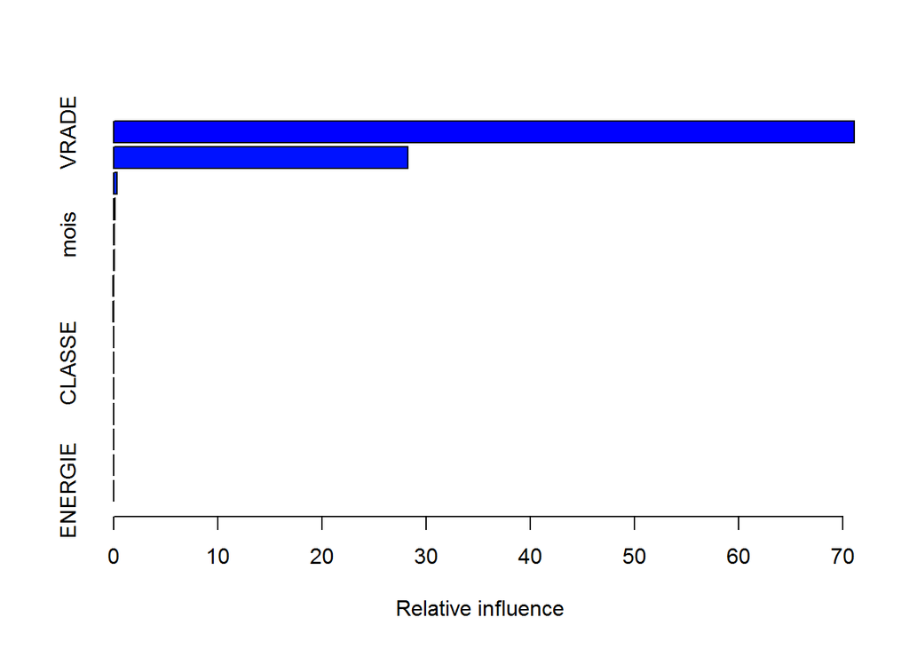

```
##                                 var      rel.inf
## VRADE                         VRADE 71.085155382
## NOM_COM                     NOM_COM 28.229719703
## PRIXACT                     PRIXACT  0.310011082
## KILOMETR                   KILOMETR  0.146404005
## mois                           mois  0.093075636
## COUT_ACTU_OPTIQUE COUT_ACTU_OPTIQUE  0.042396126
## COUT_ACTU_PIECE     COUT_ACTU_PIECE  0.039059482
## CDREGION                   CDREGION  0.038412809
## COUT_ACTU_PBRISE   COUT_ACTU_PBRISE  0.006693309
## CLASSE                       CLASSE  0.004835126
## COUT_CHOC_ARR_EU   COUT_CHOC_ARR_EU  0.003079503
## COUT_CHOC_AVT_EU   COUT_CHOC_AVT_EU  0.001157837
## CDENTITE                   CDENTITE  0.000000000
## GENRE                         GENRE  0.000000000
## ENERGIE                     ENERGIE  0.000000000
```

```
##      1        0.0118          0.0127     0.0050    0.0000
##      2        0.0118          0.0127     0.0050    0.0000
##      3        0.0118          0.0127     0.0050    0.0000
##      4        0.0118          0.0127     0.0050    0.0000
##      5        0.0118          0.0127     0.0050    0.0000
##      6        0.0117          0.0127     0.0050    0.0000
##      7        0.0117          0.0127     0.0050    0.0000
##      8        0.0117          0.0126     0.0050    0.0000
##      9        0.0117          0.0126     0.0050    0.0000
##     10        0.0117          0.0126     0.0050    0.0000
##     20        0.0115          0.0126     0.0050    0.0000
##     40        0.0112          0.0125     0.0050   -0.0000
##     60        0.0110          0.0125     0.0050   -0.0000
##     80        0.0108          0.0125     0.0050   -0.0000
```

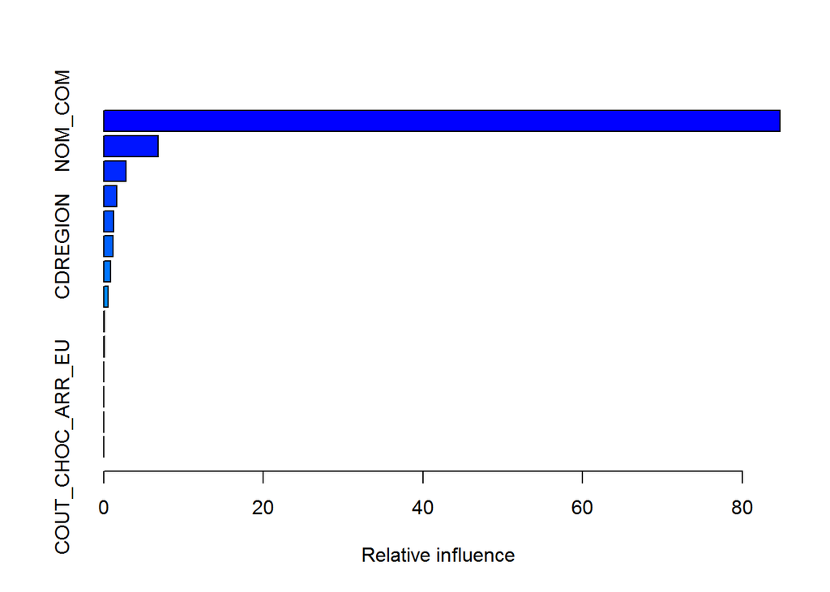

```
##                                 var     rel.inf
## NOM_COM                     NOM_COM 84.74022448
## KILOMETR                   KILOMETR  6.80000143
## CLASSE                       CLASSE  2.77436541
## PRIXACT                     PRIXACT  1.62401445
## mois                           mois  1.27461450
## CDREGION                   CDREGION  1.20156678
## COUT_ACTU_OPTIQUE COUT_ACTU_OPTIQUE  0.83319694
## COUT_ACTU_PIECE     COUT_ACTU_PIECE  0.58094869
## COUT_ACTU_PBRISE   COUT_ACTU_PBRISE  0.05443514
## COUT_CHOC_AVT_EU   COUT_CHOC_AVT_EU  0.05006637
## GENRE                         GENRE  0.03350062
## ENERGIE                     ENERGIE  0.03306519
## CDENTITE                   CDENTITE  0.00000000
## COUT_CHOC_ARR_EU   COUT_CHOC_ARR_EU  0.00000000
```

Si on retire la variable de modèle du véhicule, l’attention se focalise sur le prix à neuf et le kilométrage du véhicule.

Dommage qu’on ne dispose pas de plus d’informations sur le choc pour être sûr que cette information n’impacte vraiment pas.

```
##      1        0.0118          0.0127     0.0050    0.0000
##      2        0.0118          0.0127     0.0050    0.0000
##      3        0.0118          0.0127     0.0050    0.0000
##      4        0.0118          0.0127     0.0050    0.0000
##      5        0.0118          0.0127     0.0050    0.0000
##      6        0.0118          0.0127     0.0050    0.0000
##      7        0.0118          0.0127     0.0050    0.0000
##      8        0.0118          0.0127     0.0050    0.0000
##      9        0.0118          0.0127     0.0050    0.0000
##     10        0.0118          0.0127     0.0050    0.0000
##     20        0.0117          0.0126     0.0050    0.0000
##     40        0.0116          0.0125     0.0050    0.0000
##     60        0.0116          0.0124     0.0050    0.0000
##     80        0.0115          0.0124     0.0050    0.0000
```

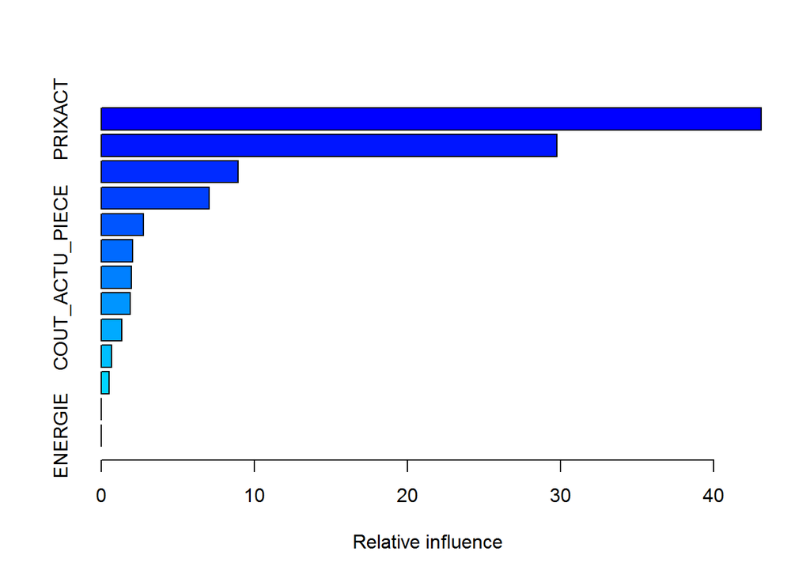

```
##                                 var    rel.inf
## PRIXACT                     PRIXACT 43.0915538
## KILOMETR                   KILOMETR 29.7435719
## mois                           mois  8.9290305
## CLASSE                       CLASSE  7.0494187
## GENRE                         GENRE  2.7470285
## CDREGION                   CDREGION  2.0333717
## COUT_ACTU_PIECE     COUT_ACTU_PIECE  1.9754929
## COUT_ACTU_PBRISE   COUT_ACTU_PBRISE  1.8935309
## COUT_CHOC_AVT_EU   COUT_CHOC_AVT_EU  1.3532422
## COUT_ACTU_OPTIQUE COUT_ACTU_OPTIQUE  0.6578718
## COUT_CHOC_ARR_EU   COUT_CHOC_ARR_EU  0.5258872
## CDENTITE                   CDENTITE  0.0000000
## ENERGIE                     ENERGIE  0.0000000
```

Répartition des montants payés finalement pour les réparations.

- 80% des réparations coutent moins de 2000€ en facture finale
- 96% des réparations coutent moins de 4000€ en facture finale
- 99% des réparations coutent moins de 6000€ en facture finale

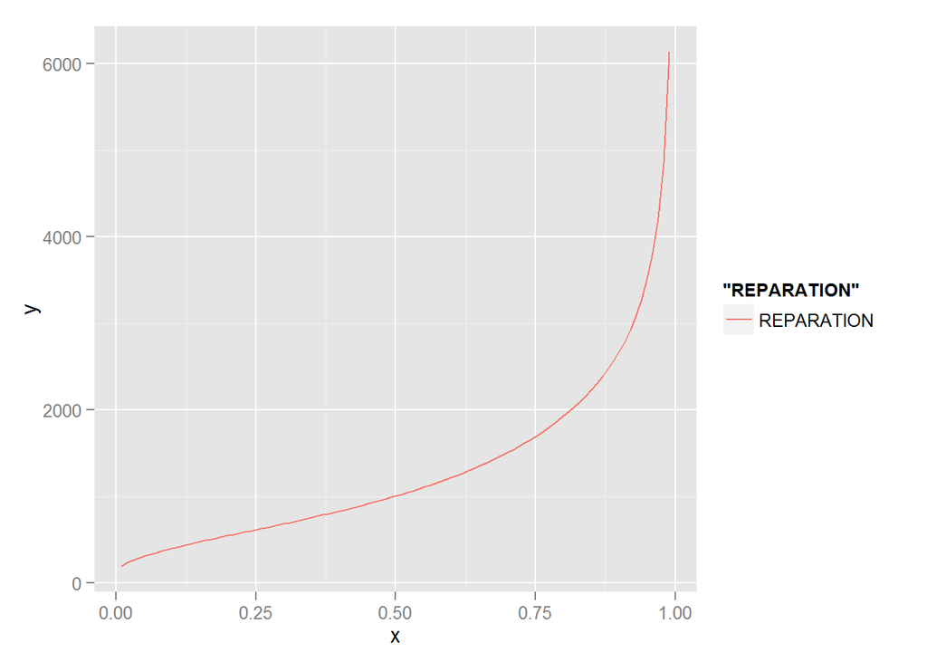

Nous appellerons “additif” l’écart entre première estimation et FACTURE FINALE

Nota : si on souhaite distinguer le vrai concept d’additif de la facture finale il faudrait peut être tenir compte d’autres paramètres : combien coûte la “reprise” du dossier par l’expert pour faire valider un additif ? Même question pour la facture finale à valider. De plus, quel crédit souhaite-t-on associer à une déclaration d’additif plutôt qu’un déclaration de coûts supplémentaires sur la facture finale ?

Répartition des additifs : modification du coût des réparations entre première évaluation et montant final

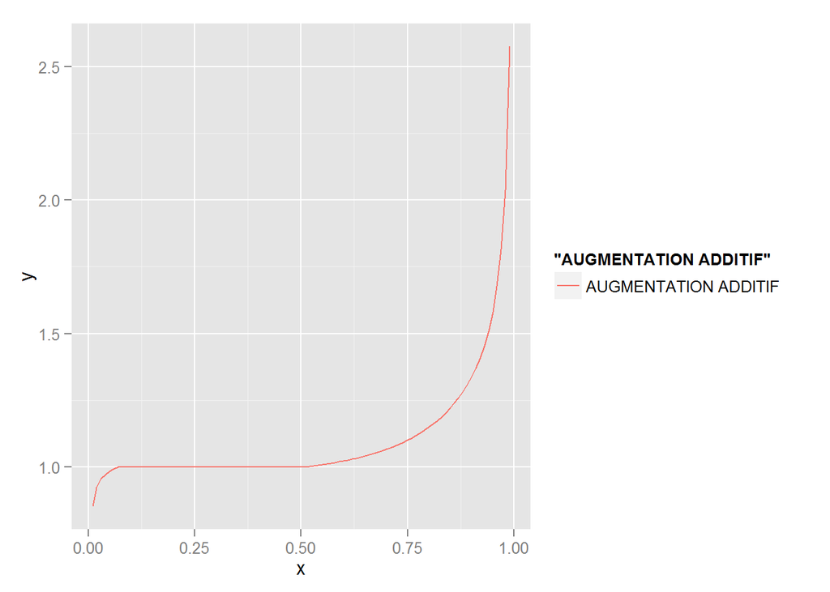

C’est une erreur structurelle parce qu’elle est due aux conditions de réalisation de la première estimation, mais dans quels cas ces augmentations sont-elles problématiques ?

Pour le savoir il faudrait une référence pour le choix d’une alternative préférence, ici VEI plutot que réparation, ie payer 100% VRADE plutôt que le montant des réparations… mais que vaut la VRADE ?

Nous verrons plus loin qu’on ne dispose d’aucun moyen d’approcher avec fiabilité la VRADE.

Nous proposons cependant une remarque sur les classes d’additifs :

Pour des centiles d’additif, valeur à neuf moyenne et coût des réparations rapporté à la valeur à neuf (non actualisée).

On observe une forte corrélation ! Ce sont les réparations les plus coûteuses à priori (pour des véhicules plus chers) qui finissent avec une facture plus élevée que prévu !

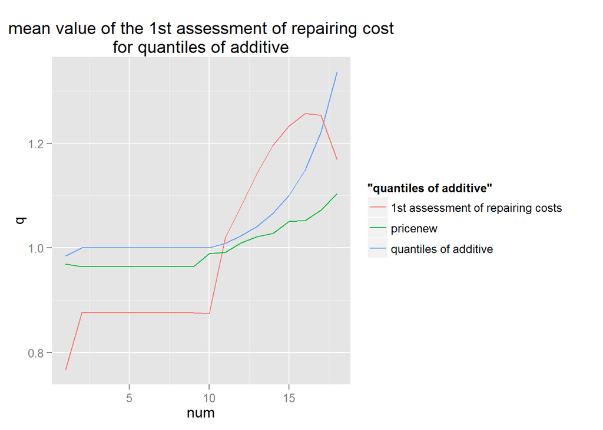

[output not shown]

[output cut: 57 more lines]

[output not shown]

[output cut: 69 more lines]

[output not shown]

[output cut: 69 more lines]

```
##      1        1.3810          1.3943     0.0500    0.0005
##      2        1.3801          1.3936     0.0500    0.0005
##      3        1.3792          1.3929     0.0500    0.0004
##      4        1.3784          1.3922     0.0500    0.0004
##      5        1.3776          1.3915     0.0500    0.0004
##      6        1.3770          1.3910     0.0500    0.0003
##      7        1.3763          1.3905     0.0500    0.0003
##      8        1.3758          1.3901     0.0500    0.0003
##      9        1.3752          1.3897     0.0500    0.0002
##     10        1.3748          1.3892     0.0500    0.0002
##     20        1.3713          1.3867     0.0500    0.0001
##     40        1.3684          1.3851     0.0500    0.0000
##     50        1.3676          1.3850     0.0500   -0.0000
```

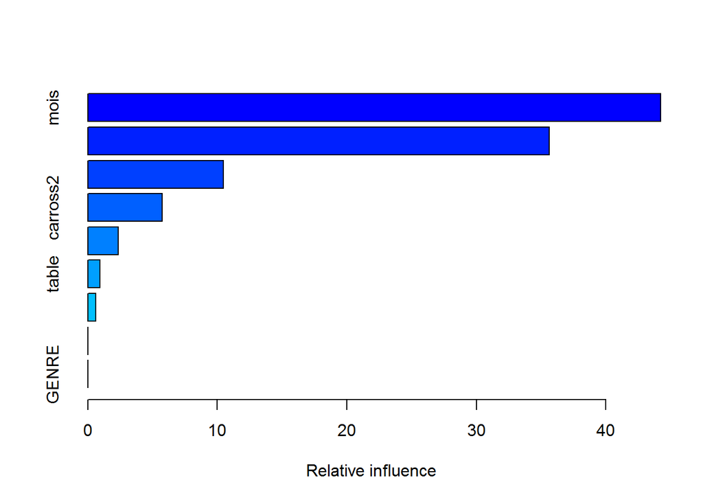

```
##               var    rel.inf
## mois         mois 44.2315570
## model2     model2 35.6348283
## PRIXACT   PRIXACT 10.4852057
## carross2 carross2  5.7420416
## marque2   marque2  2.3674344
## table       table  0.9266737
## tablekm   tablekm  0.6122593
## ENERGIE   ENERGIE  0.0000000
## GENRE       GENRE  0.0000000
```

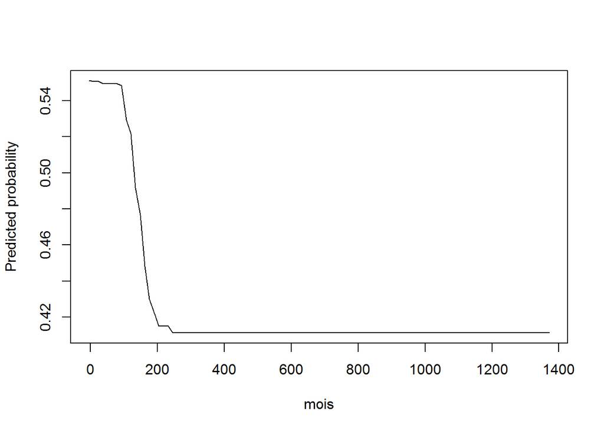

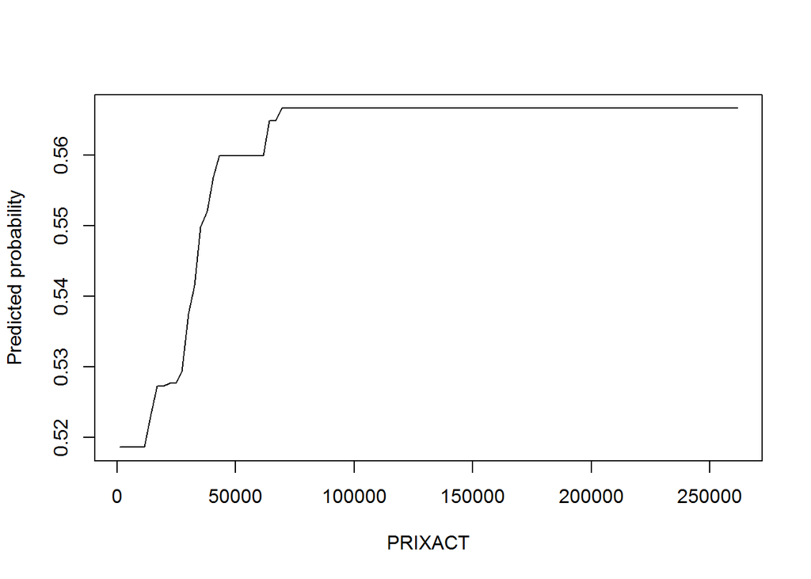

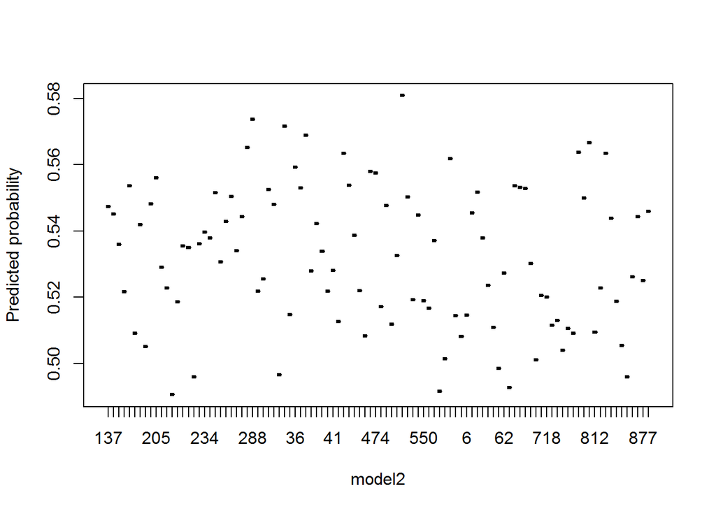

[output not shown]

```
## Using 49 trees...
```

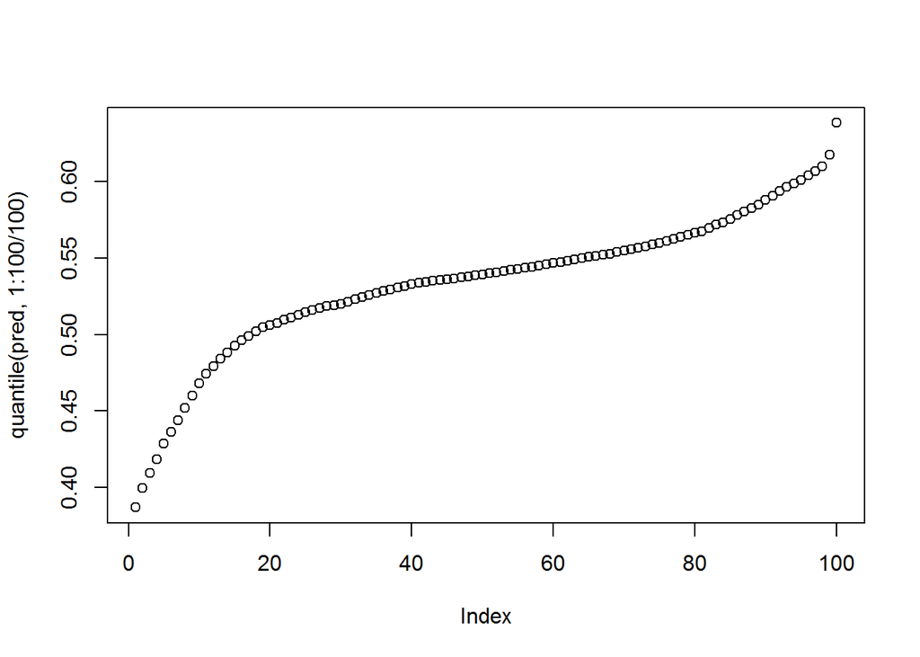

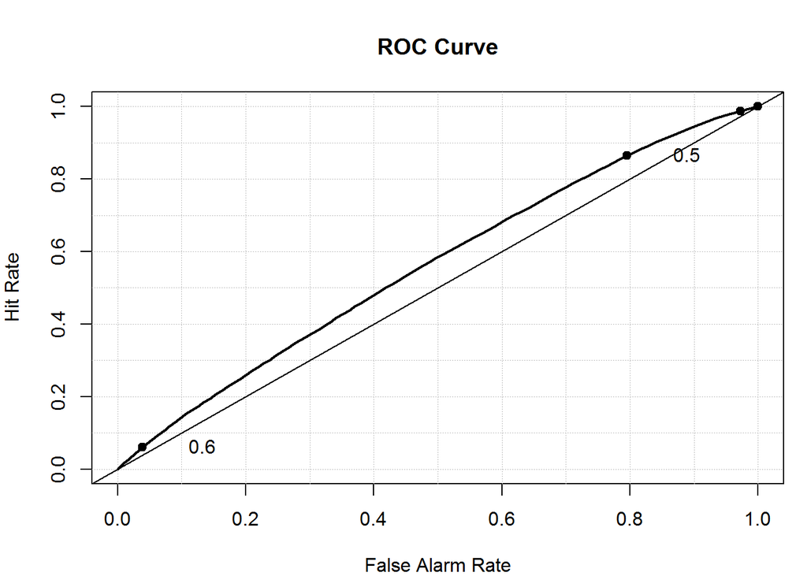

```
##      1        0.1623          0.1663     0.0500    0.0001
##      2        0.1622          0.1662     0.0500    0.0001
##      3        0.1622          0.1662     0.0500    0.0001
##      4        0.1621          0.1661     0.0500    0.0000
##      5        0.1620          0.1661     0.0500    0.0000
##      6        0.1620          0.1661     0.0500    0.0000
##      7        0.1619          0.1660     0.0500    0.0000
##      8        0.1619          0.1660     0.0500    0.0000
##      9        0.1618          0.1660     0.0500    0.0000
##     10        0.1618          0.1660     0.0500    0.0000
##     20        0.1615          0.1659     0.0500    0.0000
##     40        0.1612          0.1659     0.0500   -0.0000
##     50        0.1612          0.1659     0.0500   -0.0000
```

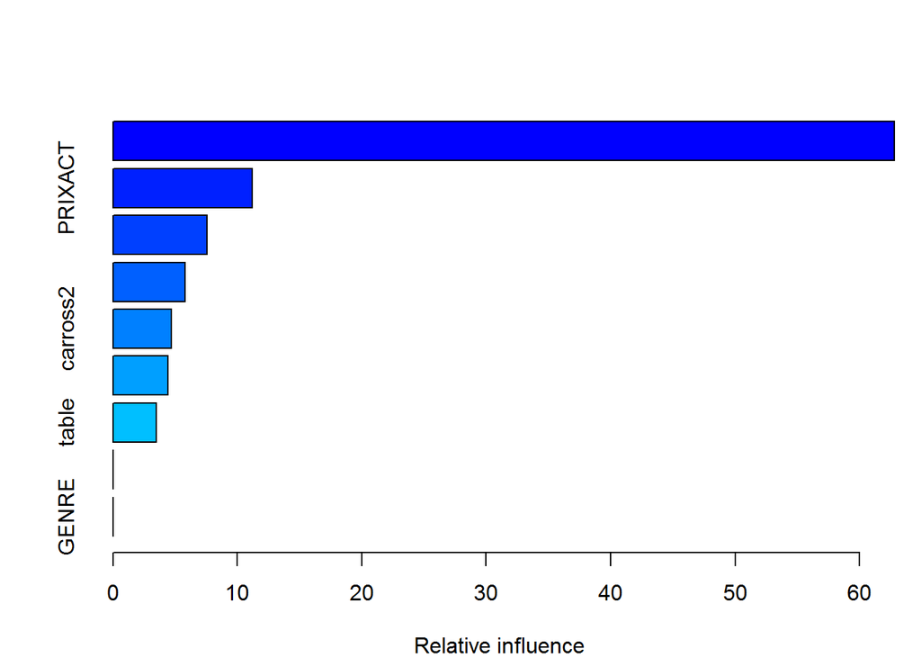

```
##               var   rel.inf
## model2     model2 62.789565
## PRIXACT   PRIXACT 11.186228
## marque2   marque2  7.571061
## mois         mois  5.798293
## carross2 carross2  4.720169
## tablekm   tablekm  4.445483
## table       table  3.489200
## ENERGIE   ENERGIE  0.000000
## GENRE       GENRE  0.000000
```

La modélisation (Gradient Boosting avec des arbres C4.5) de la VRADE sur 53000 VEI est très mauvaise. On est sur un écart type de 2295€.

On supprime les éléments trop mal modélisés (erreur de plus de 5000€), il reste 51309 observations, on refait tourner. On passe à un écart type de 1483€.

C’est mieux mais ça reste très mauvais relativement à notre objectif : on souhaiterait une erreur de l’ordre de quelques centaines d’euros au plus.

Pour mémoire, si on essaie de modéliser le ratio VRADE/PRIX NEUF, on arrive finalement à une erreur sur VRADE de 1614€ avec la même structure d’erreur.

Nous allons montrer que nous ne parvenons pas à obtenir une bonne approximation de la VRADE.

Au risque de “sur-apprendre”, on réplique la prévision sur l’échantillon d’apprentissage ce qui devrait donner des résultats plus optimistes que ceux qu’on peut obtenir en réalité.

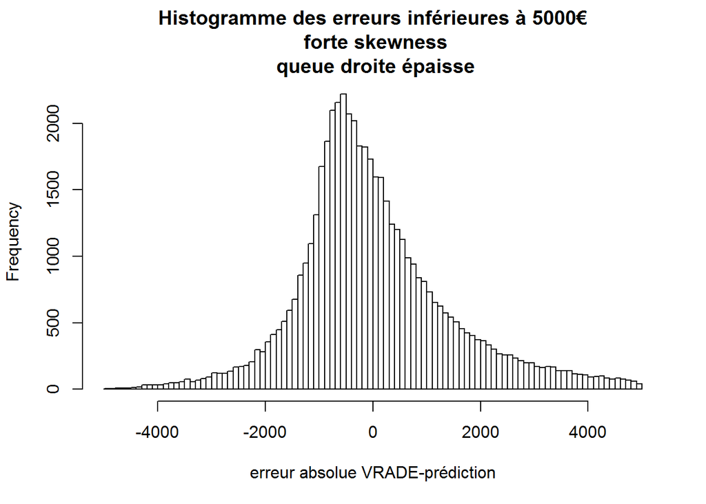

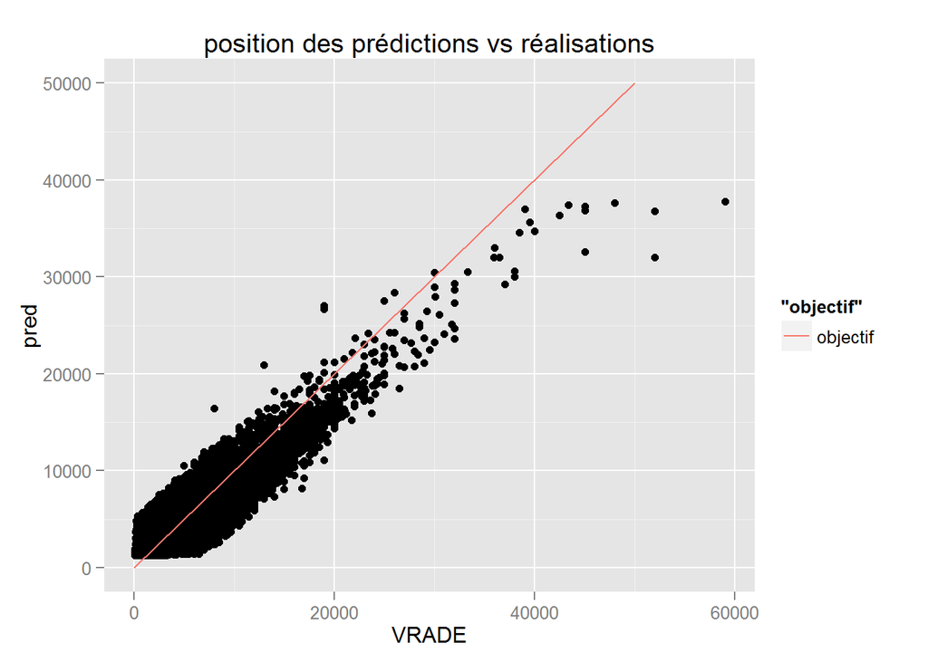

A titre d’exemple on peut répliquer la même analyse pour le Bilan technique, on se rend compte que la structure d’erreur et bien plus dispersée, des queues bien plus épaisses, un écart type à 7400€ !

```
## [1] 7395.411
```

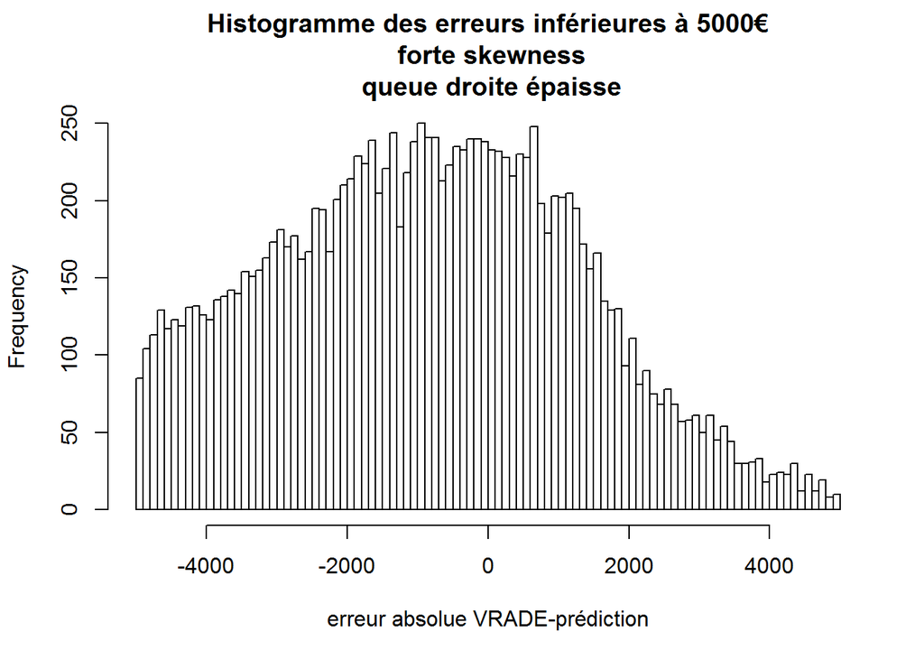

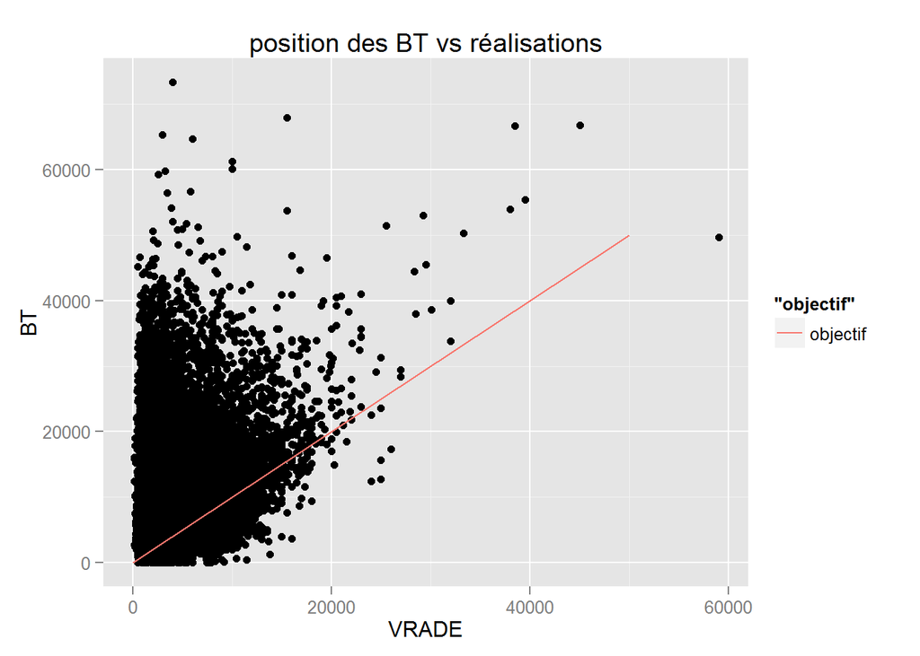

Il faut retenir que la VRADE résulte d’une négociation avec le client sur la base de la valeur argus, valeur à neuf, valeur de marché actuelle et surtout une négociation en fonction des spécificités : réparations récentes, intérêt spécifique du véhicule…

On propose ci-dessous d’autres visualisation des erreurs des modèles d’approximation de la VRADE, on peut ainsi comparer l’efficacité des approches.

On a une confiance de +/-10% sur la VRADE prédite dans à peine 20% des cas, +/-50% sur la VRADE prédite dans 65% des cas. C’est clairement insuffisant pour mesurer des impacts et des manques à gagner.

C’est certes un peu mieux que l’approximation par le prix d’origine ou pire une valeur unique de VRADE moyenne, mais ça reste insuffisant.

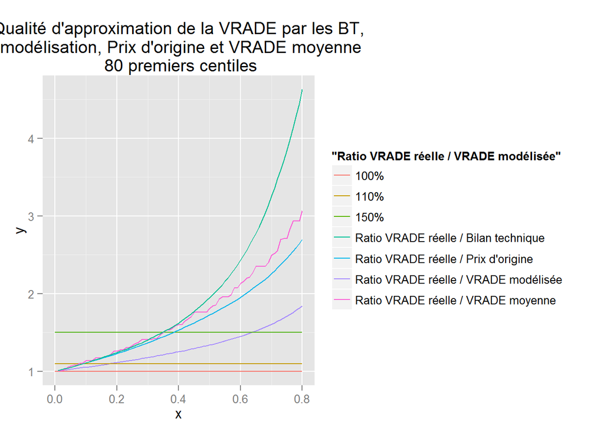

Quelles régularités dans les écarts entre VRADE et montant proposé (BT, modélisation…)

On essaie de savoir si pour certaines classes on parvient à avoir “souvent” un écart inférieur à 500€. Pour cela il suffit d’apprendre à discerner les écarts avec des modèles de règles (arbres de décision).

On construit la variable cible : 1 si l’écart est inférieur à 500€, 0 sinon.

On définit ensuite un modèle d’apprentissage sur ce {0;1} avec toutes les variables disponibles.

Pour le bilan technique s’attend à ce que les principaux facteurs soient le modèle, l’écart au kilométrage de référence et l’âge du véhicule.

Ceci prouverait que les facteurs utilisés pour calculer le bilan technique sont aussi ceux qui justifient les écarts à la VRADE.

Peut être que ces mêmes quantités sont exploitées (très) différemment dans le calcul de la VRADE.

Cette intuition est validée par la pratique par le diagramme des influences relatives. Dans l’ordre, les 4 variables principalement retenues sont le modèle de véhicule, l’écart à la référence kilométrique, le sens de cet écart (plus ou moins value kilométrique) et l’âge du véhicule.

Ceci prouve bien que le bilan technique n’est pas adéquat, ie les coefficients ne sont pas bien étalonnés.

Le principal chiffre à retenir est qu’un écart inférieur à 500€ entre BT et VRADE représente seulement 10% des cas.

```
##    Min. 1st Qu.  Median    Mean 3rd Qu.    Max.
##  0.0000  0.0000  0.0000  0.1039  0.0000  1.0000
```

```
##      1        0.6456          0.7417     0.0100    0.0011
##      2        0.6429          0.7398     0.0100    0.0010
##      3        0.6404          0.7382     0.0100    0.0011
##      4        0.6379          0.7362     0.0100    0.0009
##      5        0.6356          0.7347     0.0100    0.0009
##      6        0.6330          0.7328     0.0100    0.0010
##      7        0.6307          0.7311     0.0100    0.0009
##      8        0.6284          0.7292     0.0100    0.0009
##      9        0.6261          0.7277     0.0100    0.0008
##     10        0.6237          0.7260     0.0100    0.0009
##     20        0.6034          0.7119     0.0100    0.0007
##     40        0.5728          0.6918     0.0100    0.0005
##     60        0.5508          0.6798     0.0100    0.0003
##     80        0.5346          0.6717     0.0100    0.0002
##    100        0.5213          0.6670     0.0100    0.0001
##    120        0.5120          0.6640     0.0100    0.0000
##    140        0.5041          0.6622     0.0100    0.0001
##    150        0.5004          0.6613     0.0100    0.0000
```

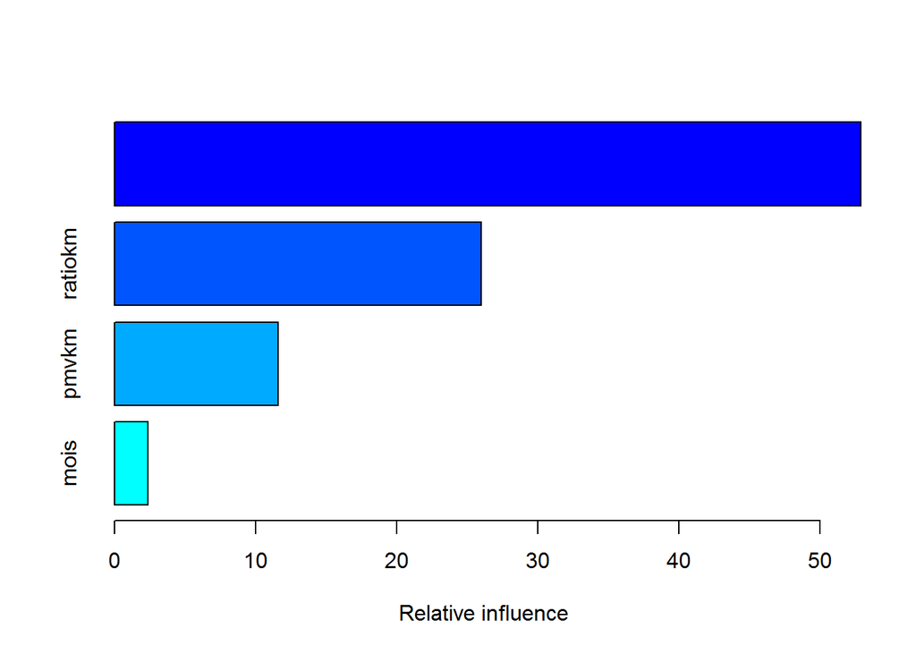

```
##                           var     rel.inf
## NOM_COM               NOM_COM 52.90899479
## ratiokm               ratiokm 25.99009543
## pmvkm                   pmvkm 11.58266745
## mois                     mois  2.37585263
## km                         km  1.99504483
## coeff                   coeff  1.37193331
## table                   table  1.28895911
## diffkm                 diffkm  1.26264655
## iiactu                 iiactu  0.77062019
## PRIXACT               PRIXACT  0.21953050
## CARROSS               CARROSS  0.15312249
## VIT_MAXI             VIT_MAXI  0.03032527
## EMISSION_CO2     EMISSION_CO2  0.01765842
## CYLINDRE             CYLINDRE  0.01661761
## BOIT_VIT             BOIT_VIT  0.01593142
## PUIS_REE             PUIS_REE  0.00000000
## ENERGIE               ENERGIE  0.00000000
## GENRE                   GENRE  0.00000000
## FREIN                   FREIN  0.00000000
## CTRL_DYN_STAB   CTRL_DYN_STAB  0.00000000
## SERILIM               SERILIM  0.00000000
## NBRE_PTE             NBRE_PTE  0.00000000
## DIR_ASS               DIR_ASS  0.00000000
## ctte                     ctte  0.00000000
## TRANS                   TRANS  0.00000000
## COUPLE_MOT_MAX COUPLE_MOT_MAX  0.00000000
```

```
## Using 150 trees...
```

Ci-dessous les effets ceteris paribus des variables les plus influentes sur la régularité d’un écart <500€

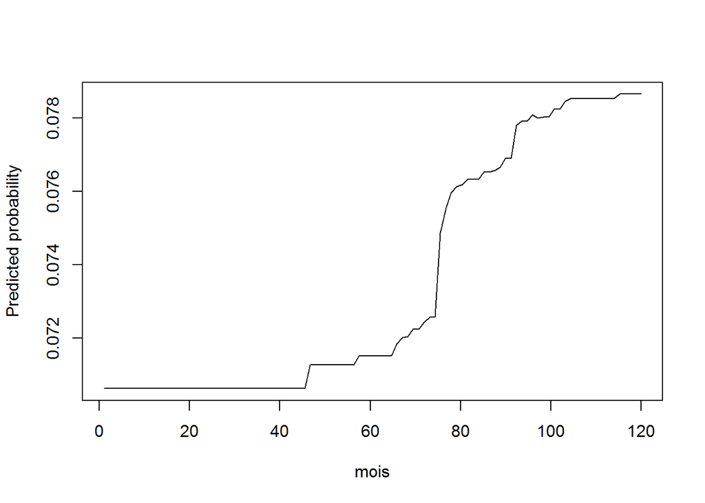

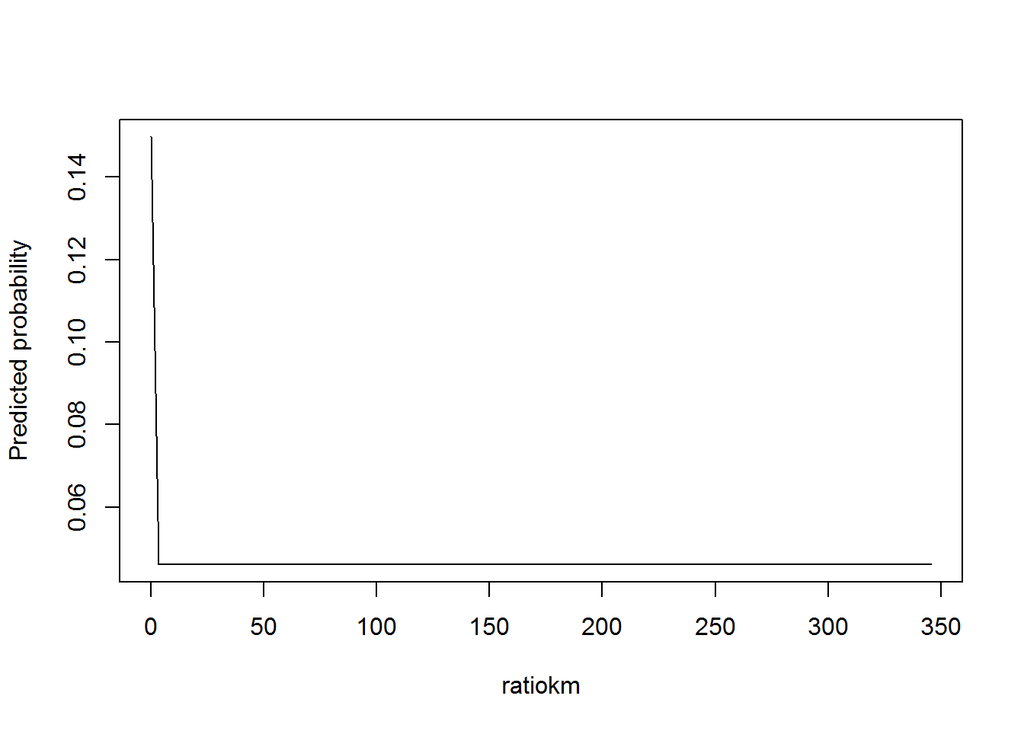

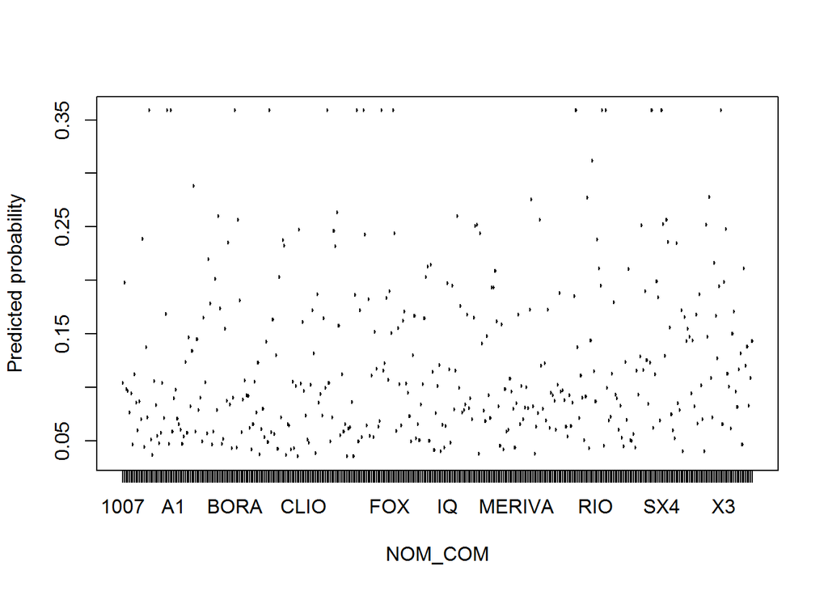

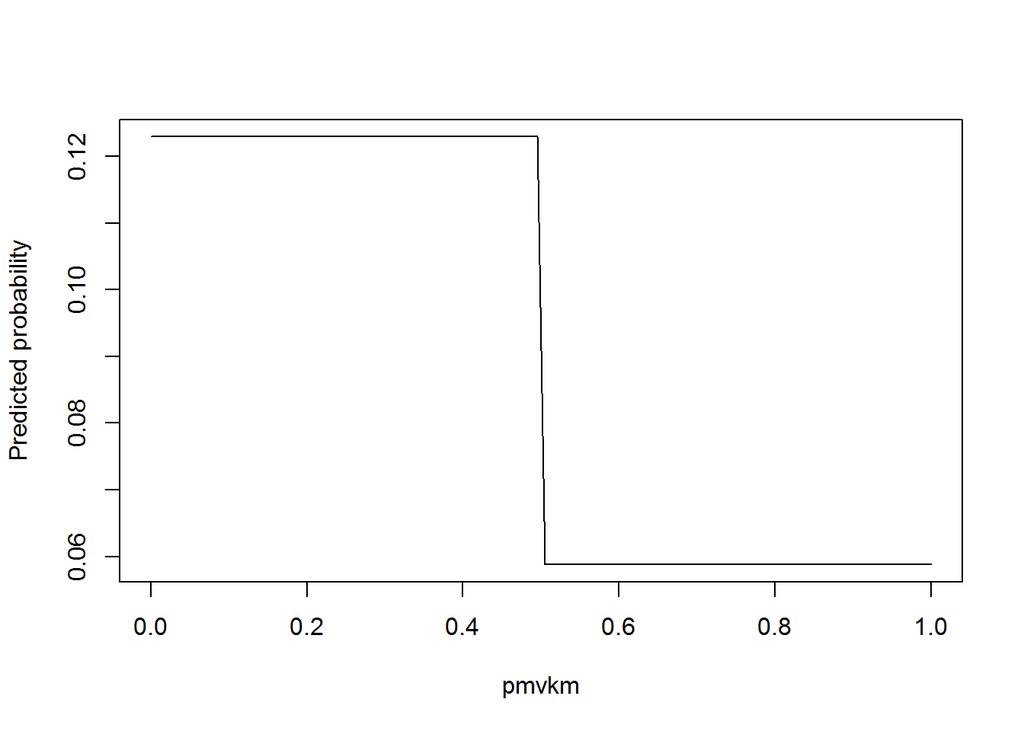

Malgré une bonne segmentation, dans 99% des cas on ne parvient pas dépasser 40% de probabilité d’écart BT-VRADE<500€.

```
## Using 150 trees...
```

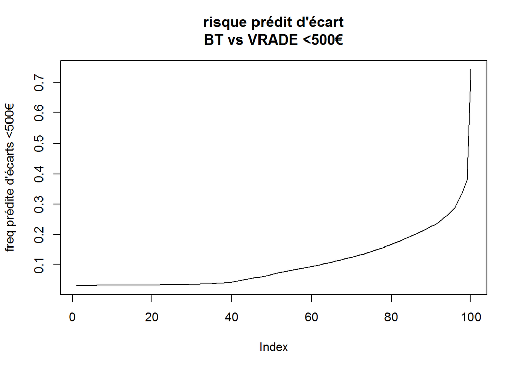

Retour sur les valeurs réelles : dans ce même échantillon, combien de véhicules par modèle avec un écart entre réference kilométrique et distance réelle parcourue inférieur/supérieur à 100%.

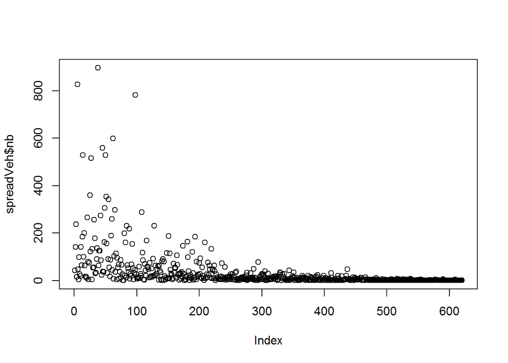

On compte le nombre de BT proches de VRADE (écart<500€) pour chaque modèle de véhicule selon l’écart entre référence kilométrique et distance réelle parcourue.